# Trading ETF’s - The sequel, Daniel Emil Wiinberg S133232

```r
D <- read.table("finans2_data.csv", header = TRUE, sep = ";")
```

# Introduction to the data

```r
head(D); tail(D)
```

|  | ETF | Geo.mean | Volatility | maxTuW |
| --- | --- | --- | --- | --- |
| 1 | SPY | 0.10490378 | 2.478601 | 309 |
| 2 | MDY | 0.13954700 | 2.925897 | 327 |
| 3 | EWJ | -0.02620057 | 2.699671 | 327 |
| 4 | EWH | 0.11267242 | 3.373114 | 302 |
| 5 | EWG | 0.05038104 | 3.800206 | 177 |
| 6 | EWW | 0.08650049 | 4.073397 | 327 |

|  | ETF | Geo.mean | Volatility | maxTuW |
| --- | --- | --- | --- | --- |
| 90 | FXI | 0.14410014 | 4.6620500 | 324 |
| 91 | IAU | 0.12507213 | 2.8521063 | 333 |
| 92 | SLV | 0.02909721 | 4.8307408 | 333 |
| 93 | USO | -0.27565080 | 4.8030638 | 319 |
| 94 | SHY | 0.01321481 | 0.1965787 | 375 |
| 95 | TLT | 0.08273749 | 2.0187989 | 182 |

The data contain 95 rows of data (excluding header), one for each ETF. Each row contain 3 columns for the 3 variables: Geo.mean, Volatility and maxTuw. These variables are calculated from the data used in the first project, representing the 454 weeks returns of each ETF.

- **Geo.mean** contains observations of the geometric average rate of return for the ETFs in the dataset.
- **Volatility** represents the weekly volatility which is the standard deviation of the ratio between the price of an ETF at the beginning of a week and the end.
- **maxTuW** is Maximum Time under Water, and indicates the maximum number of weeks between two peak prices.

## Scatterplots

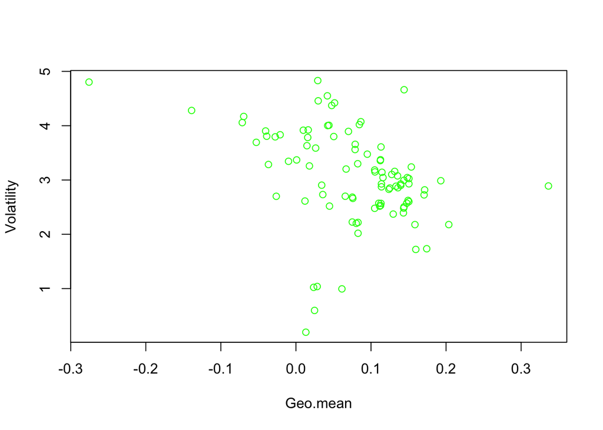

```r
# Scatterplot
plot(c(D$Geo.mean), c(D$Volatility), type="p", xlab="Geo.mean",
     ylab="Volatility", col=c("green"), cex=1)
```

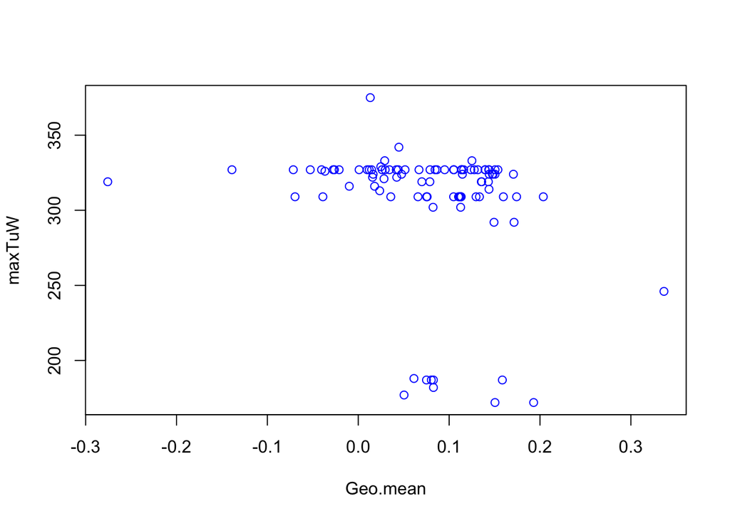

```r
plot(c(D$Geo.mean), c(D$maxTuW), type="p", xlab="Geo.mean",
     ylab="maxTuW", col=c("blue"), cex=1)
```

## Histograms

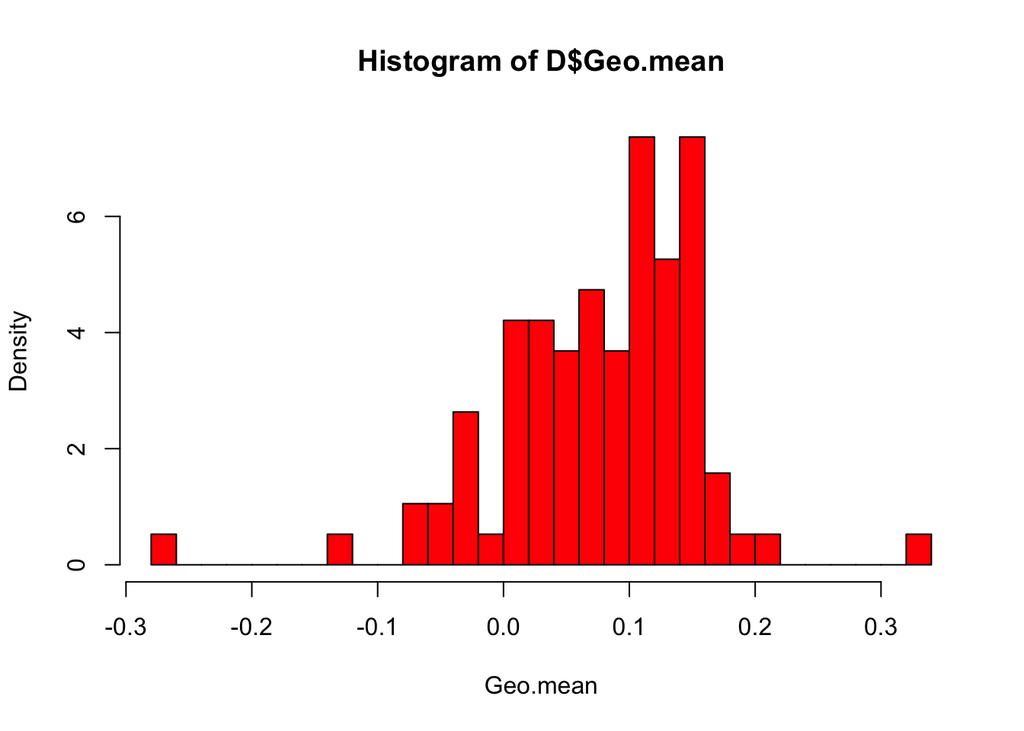

```r
# Histograms
hist(D$Geo.mean, xlab="Geo.mean", prob=TRUE, breaks = 30, col="red")
```

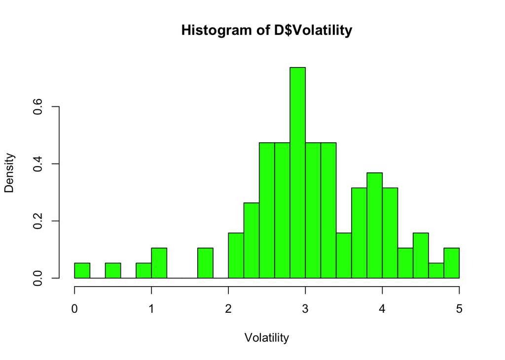

```r
hist(D$Volatility, xlab="Volatility", prob=TRUE, breaks = 30, col="green")
```

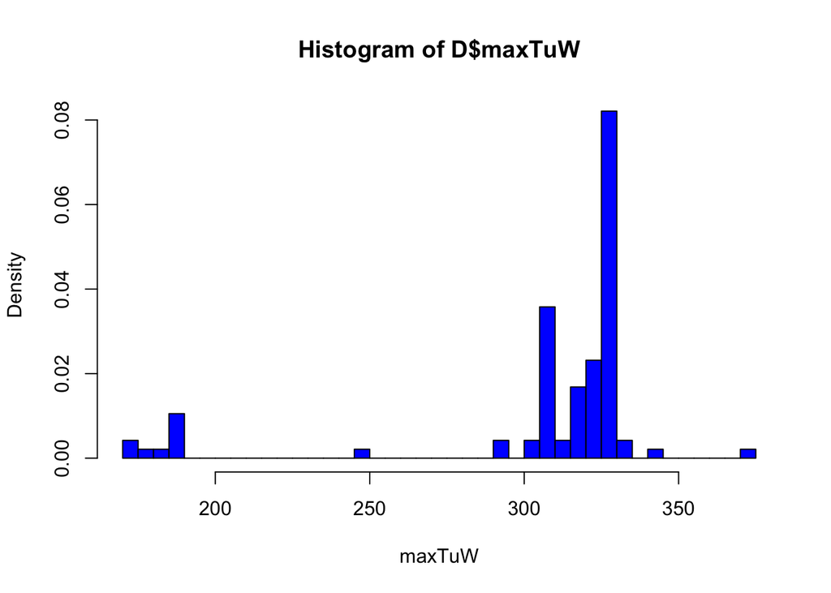

```r
hist(D$maxTuW, xlab="maxTuW", prob=TRUE, breaks = 30, col="blue")
```

## Summary table

```r
# summary(D)
# sd(D$Geo.mean)
# sd(D$Volatility
# sd(D$maxTuW)
```

|  | n | mean | sd | median | q1 | q3 |
| --- | --- | --- | --- | --- | --- | --- |
| Geo.mean | 95 | 0.07690 | 0.08087 | 0.08274 | 0.02871 | 0.1344 |
| Volatility | 95 | 3.060 | 0.8790 | 3.026 | 2.588 | 3.675 |
| maxTuW | 95 | 307.3 | 42.77 | 324.0 | 309.0 | 327.0 |

# Multiple linear regression

$$Y_i = \beta_0+\beta_1x_{1,i} + \beta_2
x_{2,i} + \epsilon_i$$
Where $Y_i$ is the geometric mean, $x_1$ is Volatility and $x_2$ is maxTuW.

```r
# Subset containing only AGG, VAW, IWN and SPY (for validation)
D_test = subset(D, ETF %in% c("AGG","VAW","IWN","SPY"))
# Subset containing only the 91 remaining ETFs (for model estimation)
D_model = subset(D, !(ETF %in% c("AGG","VAW","IWN","SPY")))
```

```r
# Estimate multiple linear regression model
fit = lm(Geo.mean ~ Volatility + maxTuW, data = D_model)

# Show parameter estimates etc.
summary(fit)
```

```
##
## Call:
## lm(formula = Geo.mean ~ Volatility + maxTuW, data = D_model)
##
## Residuals:
##      Min       1Q   Median       3Q      Max
## -0.28946 -0.05088  0.02092  0.04937  0.23927
##
## Coefficients:
##               Estimate Std. Error t value Pr(>|t|)
## (Intercept)  0.2528394  0.0584827   4.323 4.04e-05 ***
## Volatility  -0.0351310  0.0097229  -3.613 0.000503 ***
## maxTuW      -0.0002203  0.0001910  -1.154 0.251795
## ---
## Signif. codes:  0 '***' 0.001 '**' 0.01 '*' 0.05 '.' 0.1 ' ' 1
##
## Residual standard error: 0.07582 on 88 degrees of freedom
## Multiple R-squared:  0.1704, Adjusted R-squared:  0.1516
## F-statistic: 9.039 on 2 and 88 DF,  p-value: 0.0002689
```

$\beta_0$ is the interception with $x = 0$ and $\beta_1$ and $\beta_2$ are the slopes of the regression line. Meaning the the effect that $\beta_i$ has on $x_i$.

Since $\beta_1$ and $\beta_2$ are both slightly negative it means that volatility and Maximum Time under Water has a negative influence on the average return.

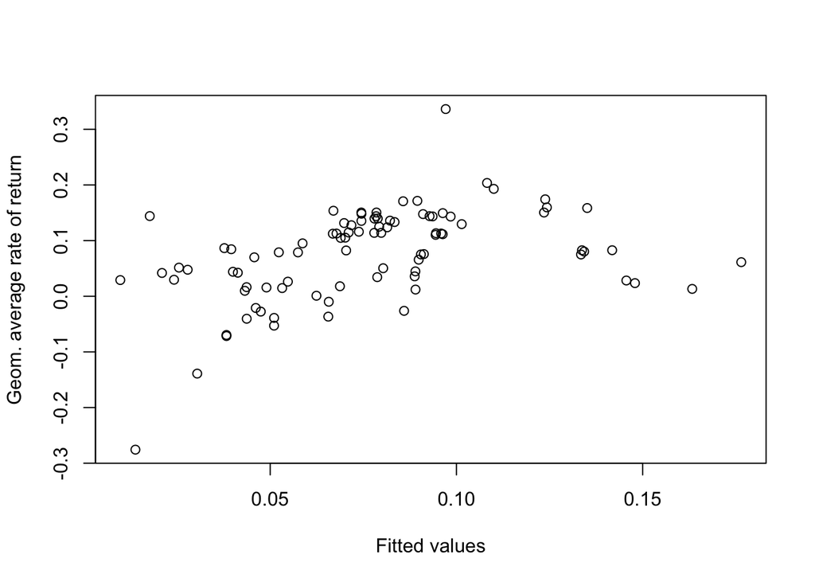

```r
# Plots for model validation
# Observations against fitted values
plot(fit$fitted.values, D_model$Geo.mean, xlab = "Fitted values",
       ylab = "Geom. average rate of return")
```

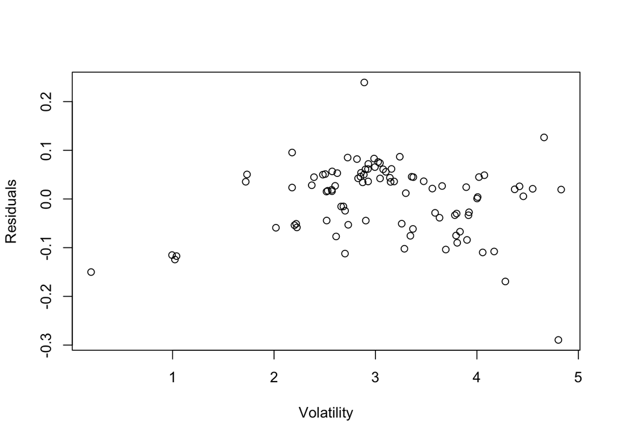

```r
# Residuals against each of the explanatory variables
plot(D_model$Volatility, fit$residuals,
     xlab = "Volatility", ylab = "Residuals")
```

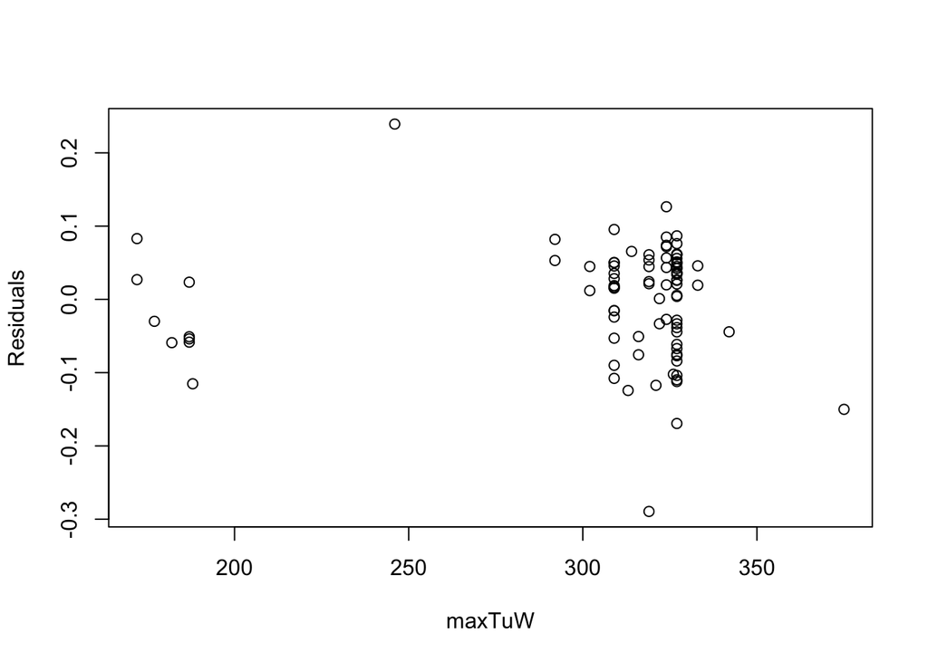

```r
plot(D_model$maxTuW, fit$residuals,
     xlab = "maxTuW", ylab = "Residuals")
```

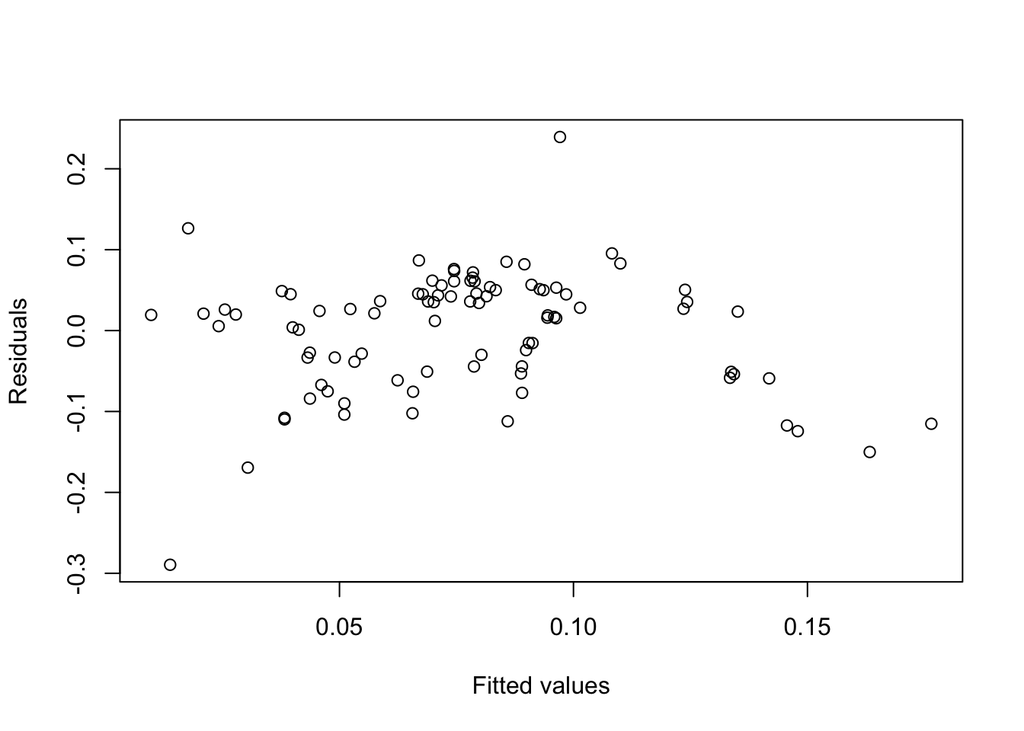

```r
# Residuals against fitted values
plot(fit$fitted.values, fit$residuals, xlab = "Fitted values",
     ylab = "Residuals")
```

From the plots of the residuals against the explanatory variables we do not see a systematic dependence.

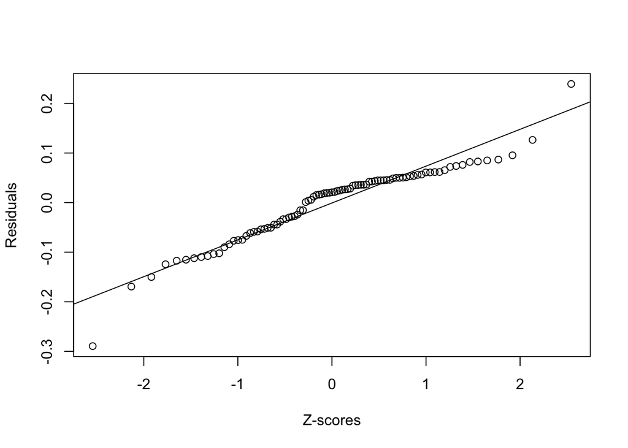

```r
# Normal QQ-plot of the residuals
qqnorm(fit$residuals, ylab = "Residuals", xlab = "Z-scores",
       main = "")
qqline(fit$residuals)
```

# Confidence interval for $\beta_1$

The confidence interval for parameter $\beta_1$ is given by:
$$\hat \beta_1 \pm t_{1-\alpha/2}\hat
\sigma_{\beta_1}$$

```r
#Confidence interval for beta_1
-0.0351310 + c(1,-1)*qt(0.975, df=88)*0.0097229
```

```
## [1] -0.01580878 -0.05445322
```

```r
# Confidence intervals for the model coefficients
confint(fit, level = 0.95)
```

```
##                     2.5 %        97.5 %
## (Intercept)  0.1366172663  0.3690616050
## Volatility  -0.0544532736 -0.0158088161
## maxTuW      -0.0005999244  0.0001592431
```

We can see that the values calculated for $\beta_1$ using the formula are the same as when using the R-function. The confidence intervals for $\beta_0$ and $\beta_2$ are also given from the R-function above.

We are testing whether $\beta_1$ might be -0.06, meaning we are testing:
$$H_{0,1}: \beta_1 = \beta_{0,1} \Rightarrow
\beta_1 = -0.06$$
Against the other hypothesis:
$$H_{1,1}: \beta_1 \neq \beta_{0,1} \Rightarrow
\beta_1 \neq -0.06$$
We are testing with a significance level of $\alpha = 0.05$.

```r
tobs = (-0.0351310 - (-0.06)) / 0.0097229
tobs
```

```
## [1] 2.557776
```

```r
# The p value becomes
2*(1-pt(tobs,df=88))
```

```
## [1] 0.01224591
```

We can see that with a $p-value = 0.0122$ we have some evidence against the hypothesis. This could also be seen from the confidence interval for $\beta_1$ being $\{-0.0545; -0.0158\}$, since $-0.06$ is outside the interval.